# R Notebook

testing

```r
devtools::load_all()
```

```
Loading Silvanus
Objects listed as exports, but not present in namespace: create_settlement
```

```r
#library(raster)
library(sf)
library(dplyr)
library(purrr)
library(furrr)
library(tidyr)
library(ggplot2)
library(tidygraph)
library(ggraph)
```

## Single population demography

First we’ll create two test populations of ten people each, one with random ages and the other with only 25 year olds.

Look at the results.

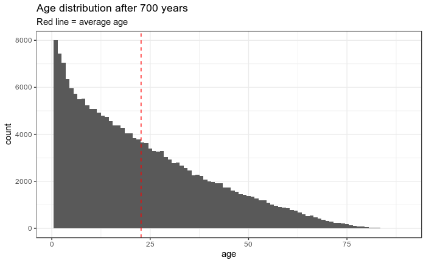

Now we can look at a food-limited population.

Reducing the food ratio from 1 to 0.8 increases infant mortality, resulting in an older and smaller population than without food limitation.

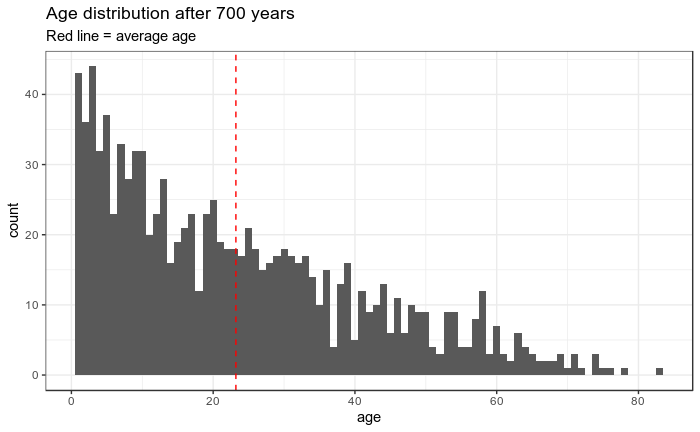

# Single settlement dynamics

[output not shown]

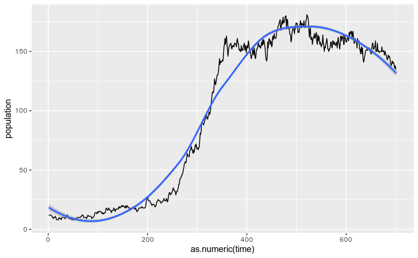

```r
farming_sim %>%
  bind_rows(.id = 'time') %>%
  group_by(time) %>%
  summarise(population = sum(occupants)) %>%
  ggplot(aes(as.numeric(time), population)) +
  geom_line() +
  geom_smooth()
```

And we can look at the age distribution of the population in a food limited environment.

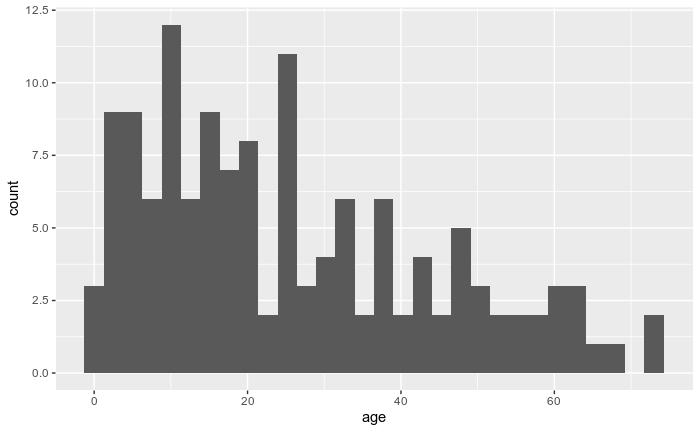

[output not shown]

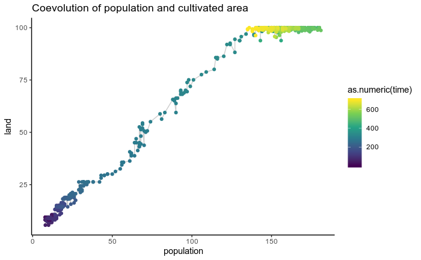

```r
farming_sim %>%
  bind_rows(.id = 'time') %>%
  group_by(time) %>%
  summarise(population = sum(occupants), land = sum(land)) %>%
  ggplot(aes(population, land)) +
  geom_line(alpha = .2) +
  geom_point(aes(color = as.numeric(time))) +
  scale_color_viridis_c() +
  theme_classic() +
  labs(title = 'Coevolution of population and cultivated area')
```

```r
profvis(accumulate(1:100, ~household_dynamics(.x), .init = test_pop3))
```

[output not shown]

```r
farming_sim2 <- 1:50 %>%
  future_map(~ accumulate(1:nsim, ~household_dynamics(.x), .init = test_pop3), .progress = TRUE)
```

[output not shown]

[output cut: 634 more lines]

[output not shown]

[output not shown]

[figure not shown]

```r
farming_sim2 %>%
  map_dfr(~bind_rows(., .id = 'time'), .id = 'rep') %>%
  mutate(time = as.numeric(time)) %>%
  filter(time < 501) %>%
  group_by(rep, time) %>%
  summarise(population = sum(occupants)) %>%
  ggplot(aes(time, population)) +
  geom_line(aes(group = rep), alpha = 0.3) +
  geom_smooth() +
  theme_classic()
```

```r
logistic_growth <- accumulate(1:500, ~.x * (1 + 0.02 * (1 - (.x / 150))), .init = 12) %>%
  tibble(time = 0:500, population = .)

farming_sim2 %>%
  map_dfr(~bind_rows(., .id = 'time'), .id = 'rep') %>%
  mutate(time = as.numeric(time)) %>%
  filter(time < 501) %>%
  group_by(rep, time) %>%
  summarise(population = sum(occupants)) %>%
  ggplot(aes(time, population)) +
  geom_line(aes(group = rep), alpha = 0.3) +
  geom_smooth() +
  geom_line(data = logistic_growth, size = 1.2, color = 'red') +
  theme_classic()
```

```r
farming_sim2 %>%
  map_dfr(~bind_rows(., .id = 'time'), .id = 'rep') %>%
  mutate(time = as.numeric(time)) %>%
  filter(time < 501 & rep == '1') %>%
  ggplot(aes(time, land, group = household)) +
  geom_line(alpha = 0.2) +
  theme_classic()
```

Developing new hh number

```r
new_hh_num <- function(x, n){
  x %>%
    pull(household) %>%
    levels %>%
    as.integer %>%
    max %>%
    `+`(1:n) %>%
    as.factor
}

t1 <- tibble(household = as.factor(1:4))

t2 <- tibble(household = new_hh_num(t1, 3))

t3 <- bind_rows(t1, t2) %>% mutate(household = as.factor(household)) %>% filter(household == 4)
t3

t4 <- tibble(household = new_hh_num(t3, 3))

bind_rows(t3, t4) %>% mutate(household = as.factor(household))
```

First we’ll look at the model behavior for just a single settlement, focusing on how equilibrium population density varies based on rainfall and other social and environmental factors.

Start by generating an experimental test population.

```r
environment <- crossing(arable = seq(0.3, 1, by = 0.05), precipitation = seq(0.3, 1, 0.05))
test_pop <- create_settlement(225, n_households = 4) %>%
  mutate(arable = environment$arable,
         precipitation = environment$precipitation,
         climatic_yield = calc_climatic_yield(precipitation))

test_pop
```

Now run the simulation for 500 years

```r
nsim <- 500
test <- reduce(1:nsim , ~household_dynamics(.x), .init = test_pop)

plan(multicore)
set.seed(1000)
test <- test_pop %>%
  mutate(chunk = rep(1:25, times = 9)) %>%
  group_by(chunk) %>%
  nest() %>%
  mutate(out = future_map(data, ~reduce(1:nsim , ~household_dynamics(.x), .init = .x), .progress = TRUE))
```

```r
test1 <- test %>%
  select(-data) %>%
  unnest %>%
  select(settlement, arable, precipitation, population) %>%
  full_join(environment) %>%
  mutate(population = if_else(is.na(population), 0, population))

test1 %>%
  filter(near(precipitation, 1)) %>%
  ggplot(aes(arable, population)) +
  geom_point() +
  geom_smooth(method = 'lm')

test1 %>%
  filter(near(arable, 1)) %>%
  ggplot(aes(precipitation, population)) +
  geom_point()

m1 <- mgcv::gam(population ~ s(precipitation) + s(arable), data = test1)
m2 <- mgcv::gam(population ~ te(precipitation, arable) , data = test1)

plot(m1)
plot(m2, scheme = 1)
AIC(m1,m2)
```

[output not shown]

```r
1:500 %>%
  reduce(~mutate(., households = map(households, ~reproduce(.) %>% die)), .init = test_pop) %>%
  unnest %>%
  unnest %>%
  ggplot(aes(age)) +
  geom_histogram(binwidth = 1, center = 0) +
  geom_vline(aes(xintercept = mean(age)), color = 'red', linetype = 2) +
  theme_bw()
```

Now just run 1 settlement with 1 arable and precip, repeat several times, then end with the age distribution.

```r
test_pop2 <- create_settlement(1, n_household = 4)
library(profvis)
set.seed(1000)
test_time2 <- system.time(accumulate(1:600, ~household_dynamics(.x), .init = test_pop2))

set.seed(1000)
profvis(test4 <- accumulate(1:600, ~household_dynamics(.x), .init = test_pop2))

test3 <- 1:20 %>%
  future_map(~accumulate(1:600, ~household_dynamics(.x), .init = test_pop2), .progress = TRUE)

test3 %>%
  map_dfr(~bind_rows(., .id = 'time') %>% select(time, population), .id = 'rep') %>%
  ggplot(aes(as.numeric(time), population, group = rep)) +
  geom_line()

test3 %>%
  select(-data) %>%
  unnest %>%
  filter(arable == 1, precipitation == 1) %>%
  unnest %>%
  unnest %>%
  unnest %>%
  ggplot(aes(age)) +
  geom_histogram(binwidth = 5, center = 0) +
  geom_vline(aes(xintercept = mean(age)), color = 'red', linetype = 2) +
  theme_bw()
```

should test to see if all the dplyr mutates and joins and whatever are faster or slower with more columns

```r
foodlim <- readr::read_csv('../../Foodlim_R_code/demog_vectors.csv')
```

This is where the default demographic data that comes with the package gets made. Need to improve.

```r
fertility_table <- tibble(
  age = 0:119,
  fertility_rate = c(rep(0, 12), 0.022, 0.022, 0.022, rep(c(0.232, 0.343, 0.367, 0.293, 0.218, 0.216, 0.134), each = 5), rep(0, 70))
)

mortality_table <- tibble(
  age = 0:119,
  mortality_rate = c(0.381, rep(0.063, 4), rep(c(0.013, 0.010, 0.013, 0.016, 0.018, 0.020, 0.022, 0.024, 0.025, 0.033, 0.042, 0.062,
                                                 0.084, 0.122, 0.175, 0.254, 0.376, 0.552, 0.816, 1, 1, 1, 1), each = 5)),
  survivor_shape = foodlim$mortparms
)

life_table <- left_join(fertility_table, mortality_table)
usethis::use_data(life_table, internal =  TRUE, overwrite = TRUE)
usethis::use_testthat()

plot(fertility_table)
```

# Migration

```r
hex <- rbind(c(0,0), c(100,0), c(100,100), c(0,100), c(0,0)) %>%
  list %>%
  st_polygon %>%
  st_sfc %>%
  st_make_grid(square = FALSE)

pts <- st_centroid(hex)

# dist <- st_intersects(hex, sparse = TRUE) %>%
#   as_tibble %>%
#   rename(from = row.id, to = col.id) %>%
#   mutate(distance = st_distance(pts[from], pts[2], by_element = TRUE))

dist <- st_distance(pts) %>%
  `rownames<-`(1:length(pts)) %>%
  `colnames<-`(1:length(pts))

dist_edgelist <- list(
  from = rownames(dist)[row(dist)] %||% row(dist),
  to = colnames(dist)[col(dist)] %||% col(dist),
  weight = dist
  ) %>%
  map_dfc(as.vector) %>%
  mutate_if(is.character, as.integer)


#filter(near(weight, 10))

settlements <- create_settlement(length(hex)) %>%
  mutate(population = 10,
         x = st_coordinates(pts)[,1],
         y = st_coordinates(pts)[,2],
         geometry = pts) %>%
  tbl_graph(edges = dist_edgelist, directed = TRUE) %E>%
  rename(distance = weight)

settlements

ggraph(settlements) +
  geom_edge_link() +
  geom_node_point(aes(size = population)) +
  coord_fixed() +
  theme_void()

settlements %N>%
  mutate(edge = centrality_degree() < 6)

# full <- igraph::distances(settlements, mode = 'out') %>%
#   as_tbl_graph %>%
#   mutate(settlement = 1:n()) %E>%
#   mutate(type = 'route')

# graph_join(settlements, full) %>%
#   filter(type == 'route') %>%
#   ggraph() +
#   geom_edge_link()
```

```r
settlements %E>%
  filter(near(weight, 10)) %>%
  ggraph() +
  geom_edge_link() +
  geom_node_point(aes(size = population)) +
  coord_equal() +
  theme_void()
```

```r
test <- settlements %N>%
  mutate(attractiveness = 10, pop_start = 10)


 reduce(1:100, ~interact2(.x), .init = test) %E>%
  filter(near(distance, 10)) %>%
  ggraph() +
  geom_edge_link() +
  geom_node_point(aes(size = population)) +
  coord_equal() +
  theme_void()
```

AT some point it’d be nice to include like 10-20 percent of your food ratio, etc, as a function of the flows from other places. or maybe the flows from other places make up a pool of resources at the settlement level that the households divide amongst themselves

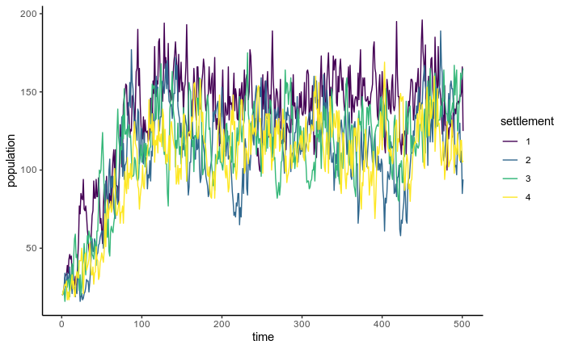

sublinear scaling of area to population in a settlement plot population vs urban area. so the maximum settlement we can hold in 1km has 25,000 people. beyond that we need more than one 1km tile

```r
tibble(population = seq(1,100000, 1000),
       area = 0.175 * population ^ 0.634) %>%
  ggplot(aes(population, area)) +
  geom_line()
```

## need a way to test if a settlement has become completely depopulated and allow it to repopulate

possible a reason to have the environental table be separate and repeatedly joined to the population table or something